# Final Project: Gun Violence

Sydney Beverly, Julia Baker, and Allaire Tetrault

2026-04-30

# Read Data

- The Gun Violence Archive contains incidents from 2015 through 2025, including information on incidents (date and location; number of people injured, killed; number of suspects injured, killed, and arrested) and information on participants in the incident (gender, age group).
- EveryShot contains incidents from 2024 and 2025, including potentially more information on incidents, victims and suspects.

# Potential Questions

- Analysis that examines or compares gun violence by types of outcomes or victims or other attributes;
- Analysis that ranks places based on different measures for a given point in time;
- **Analysis that focuses in on key places/localities to compare outcomes, experiences, or change across time;**
- Analysis that focuses on change over time to understand where outcomes are improving or worsening;
- Data tables and sources that allow others to quickly find information on places of interest, or on problems of interest;
- Lots of other possibilities that you can help identify

# Definitions

# Explore the Data

Gun violence remains a significant public health and policy issue in Virginia, with measurable impacts on both community safety and economic well-being (Johns Hopkins Center for Gun Violence Solutions n.d.).

Throughout this analysis, we move from raw data → cleaned data → summarized insights → spatial patterns → explanatory relationships.Each step builds toward understanding where gun violence occurs,who is most affected, and what contextual factors may influence outcomes. This analysis suggests that gun violence in Virginia is not only unevenly distributed geographically, but also inconsistently measured across data sources. Differences between EveryShot and GVA highlight how data collection methods shape our understanding of the problem.

Gun violence in Virginia is not evenly distributed. A locality-level comparison shows that the places with the highest total burden are not always the same places with the highest per-capita rates or fatality patterns, which is why comparing selected localities reveals more than statewide totals alone.

## Missing Data

The URI variable contains the web link to the news article used to identify the shooting incident in the EveryShot database. Its mostly missing in the everyshots suspects and victims dataset. The incidents dataset has a lot of missing data for the later categories such as gun type, school type etc.

We thought this could be a result of Every Shot Data being collected through AI, the program might have hallucinated or did not collect urls for every incident.

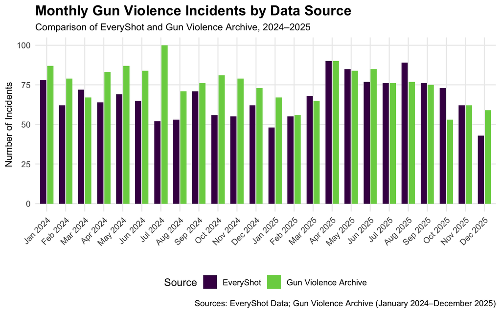

This graph above shows the differences in incidents recorded by each source. It makes us wonder why those differences exist and what would bring us closer to the real number of incidents. As we have learned, ES data is recorded through news reportings and pulled by AI while GVA is both automated and manual verification and requires to be verified by both initial researchers and secondary validation processes.

# Overview

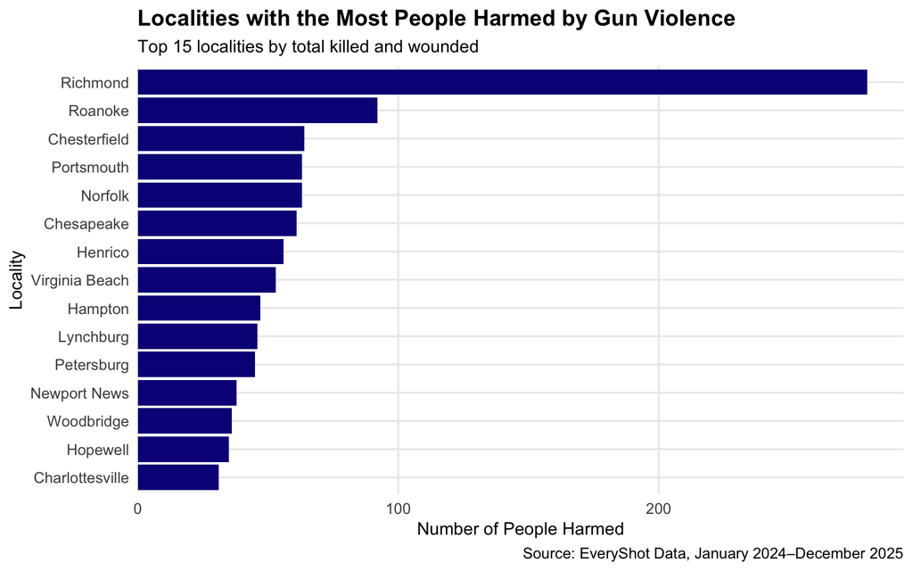

[figure not shown]

## Comparing top 10 cities with greatest reported incidents

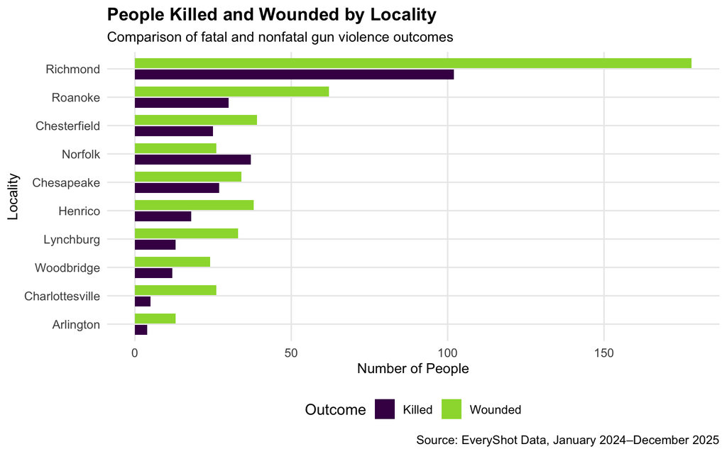

This graph compares the total number of people killed and wounded by gun violence across several Virginia cities. Richmond stands out with the highest counts in both categories, indicating not only frequent incidents but also a large number of people affected when they occur. In most cities, the number of individuals wounded exceeds those killed, suggesting that non-fatal injuries are more common outcomes. However, cities like Norfolk and Chesapeake show relatively higher proportions of fatalities, which may indicate differences in incident severity or response conditions.

# Fatality

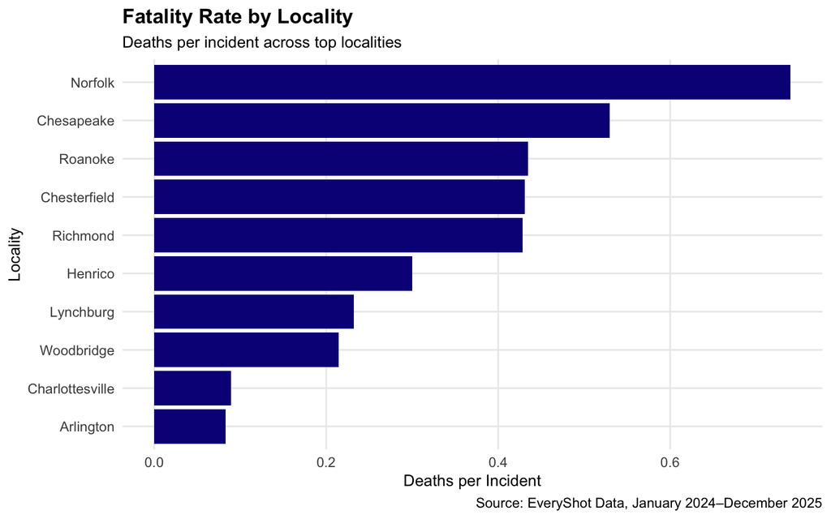

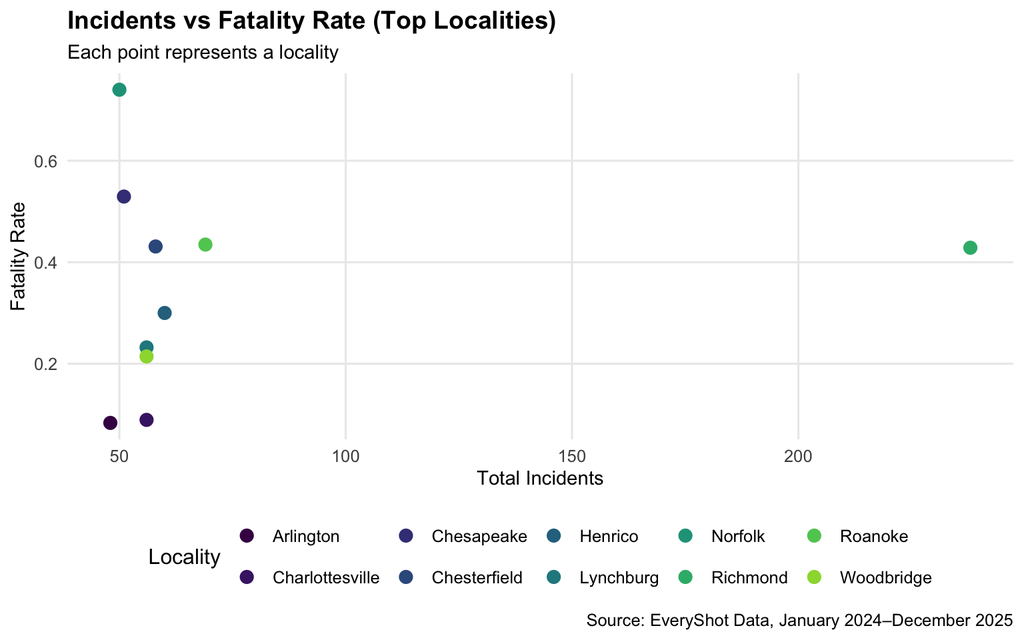

This graph illustrates the fatality rate in each city, with Norfolk having the highest rate and Chesapeake coming in second, highlighting a regional trend in the Hampton Roads area. Given that Norfolk and Chesapeake are in close proximity, it is not surprising that they show similar patterns, with higher fatality rates compared to other cities. However, these patterns may also be influenced by differences in reporting practices, such as more consistent reporting of fatalities or better follow-up on incidents compared to other cities where fatalities may be underreported. Roanoke and Chesterfield also display similar fatality trends, which is notable given their geographic differences within Virginia. Roanoke is more rural and located near the western edge of the state, where cross-state movement, such as from West Virginia, could influence patterns of violence. In contrast, Chesterfield’s proximity to Richmond may contribute to its trends, as individuals may travel from nearby urban areas. These observations suggest that geographic context and movement across regions may play a role in shaping fatality rates.Future analysis should incorporate per capita rates, and contextual factors such as access to trauma care and policing strategies to better understand the drivers of fatality differences across cities.

# Locality

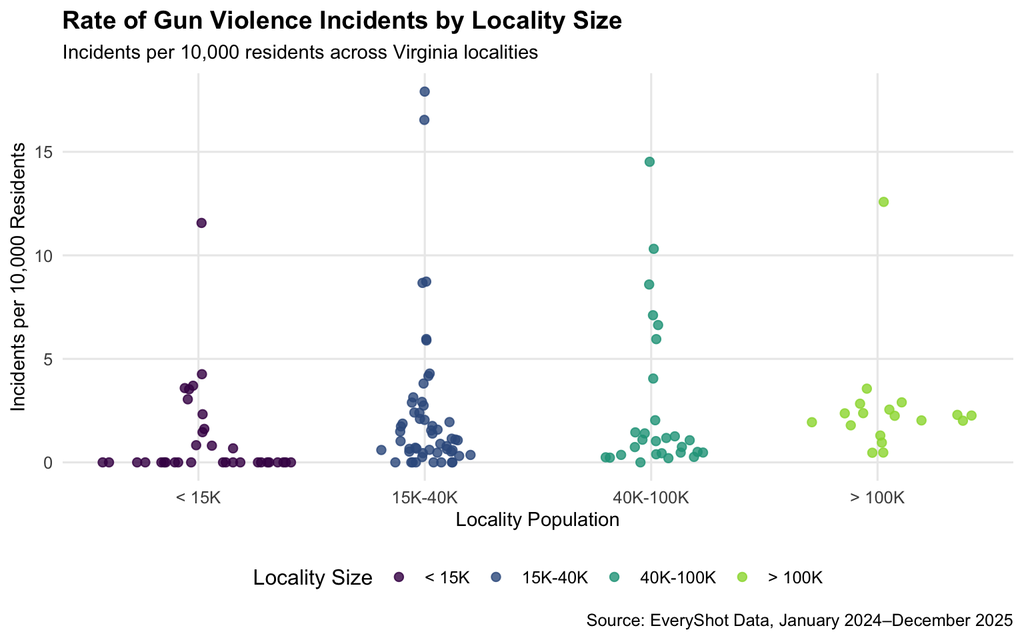

## Hotspots

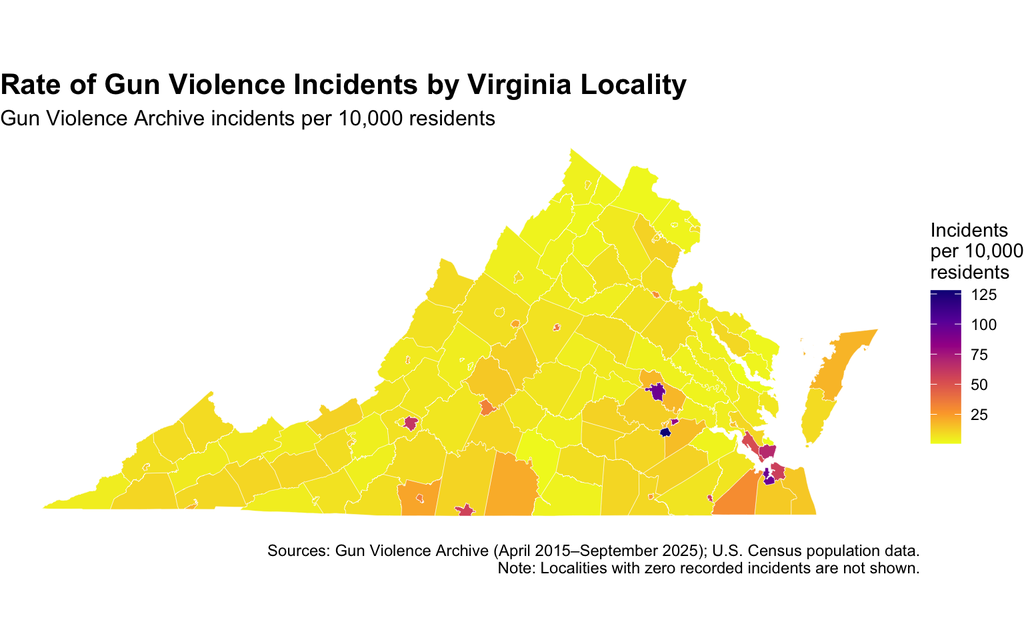

Note: Localities with zero recorded incidents are not included in this map. Unlike prior analyses limited to 2024–2025, this map uses the full available GVA dataset (April 2015–September 2025) to show longer-term geographic patterns.

High Rates: Petersburg city, Richmond city, Portsmouth city, Hopewell City and Hampton City–lots of independent cities

High incident counts: Richmond City, Norfolk city, Newport News–lots of urban and suburban population centers

### Richmond Gun Violence Hotspots

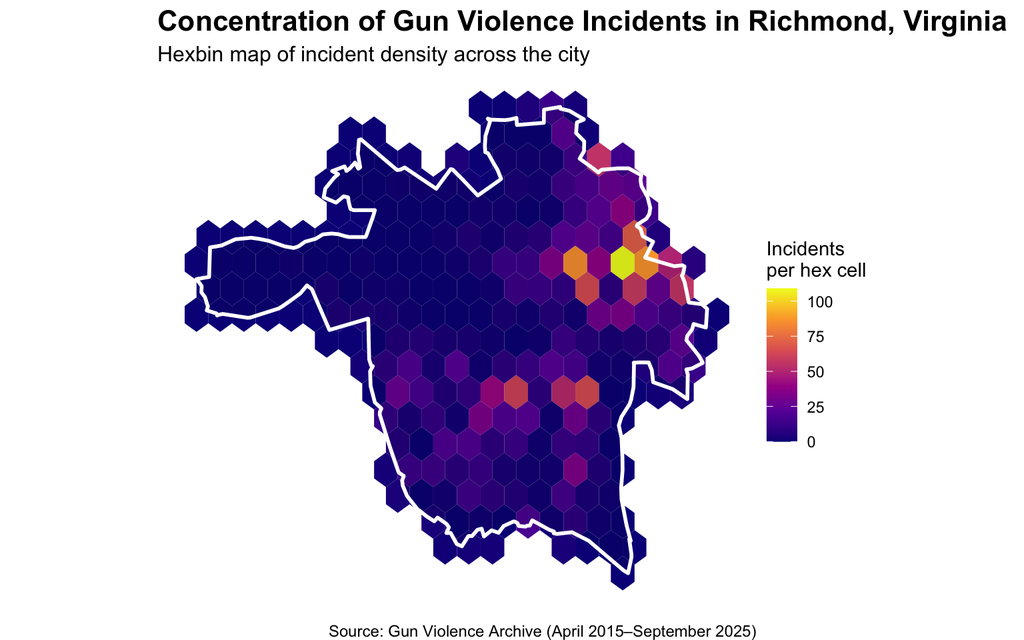

Higher-density clusters appear in eastern and southern Richmond, indicating concentrated areas of gun violence over time.

### Norfolk Gun Violence Hotspots

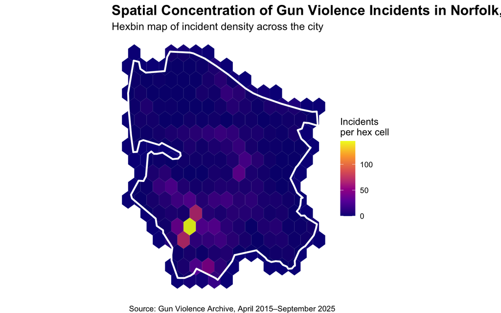

Higher-density clusters appear in southwestern Norfolk, with additional clustering across central areas, indicating concentrated patterns of gun violence over time.

### Henrico County Gun Violence Hotspots

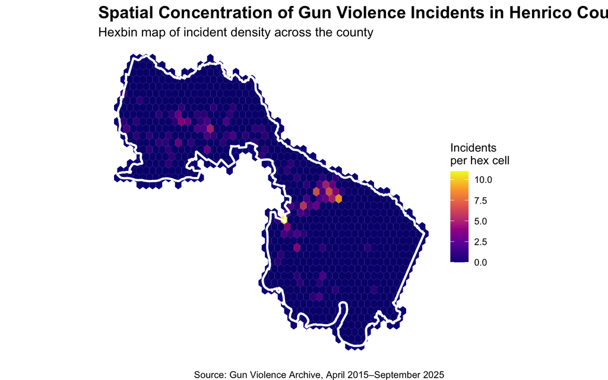

Higher-density clusters appear in eastern Henrico County, with additional clustering extending into central areas, indicating localized concentrations of gun violence over time.

### Charlottesville City Gun Violence Hotspots

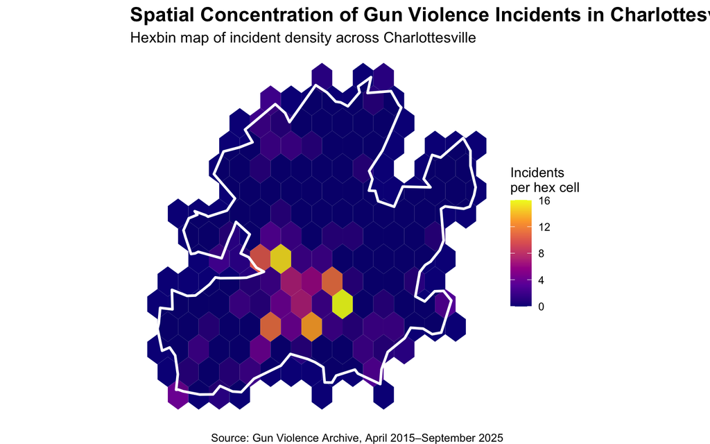

Higher-density clusters appear in central Charlottesville, indicating concentrated areas of gun violence over time.

### Albemarle County Gun Violence Hotspots

[figure not shown]

Using the Gun Violence Archive (2015–2025) we analyzed within-locality spatial patterns of gun violence. Incidents are mapped as points and aggregated into uniform hexagonal grid cells, with each hex showing the number of incidents within that area

This shows hotspots within Richmond City with major clustering around the central east area, some clustering in central southern area with few incidents in western northern part of richmond. This perhaps shows it better by putting zero incident hexagons in gray. The Norfolk map appears more tightly centered around one dominant southern cluster, with lower-intensity incidents distributed outward from that area. Compared with Richmond, Norfolk’s pattern looks somewhat more centralized, while Richmond’s looks more spatially dispersed across two main clusters. Henrico County displays a much more diffuse pattern, with lower-intensity clusters and incidents spread across a broader geographic area. Charlottesville, a smaller city, shows a localized but lower-intensity cluster, with incidents concentrated in a compact central area and little activity elsewhere.Some localities (e.g., Albemarle County) exhibit minimal or no detectable clustering due to very low incident counts, highlighting the uneven geographic distribution of gun violence across the state.

# Trauma Centers

Distance to Nearest Trauma Center by Incident Fatality Status

| fatal | Number of incidents | Mean distance (km) | Median distance (km) |
| --- | --- | --- | --- |
| Fatal incidents | 3861 | 21.4 | 8.7 |
| Nonfatal incidents | 10575 | 19.8 | 8.4 |

Fatal incidents are slightly farther away from trauma centers than non fatal incidents. The mean difference is about +1.6km, median is +.3km. since the difference is modest, distance alone is probably not the primary driver of fatal outcomes.

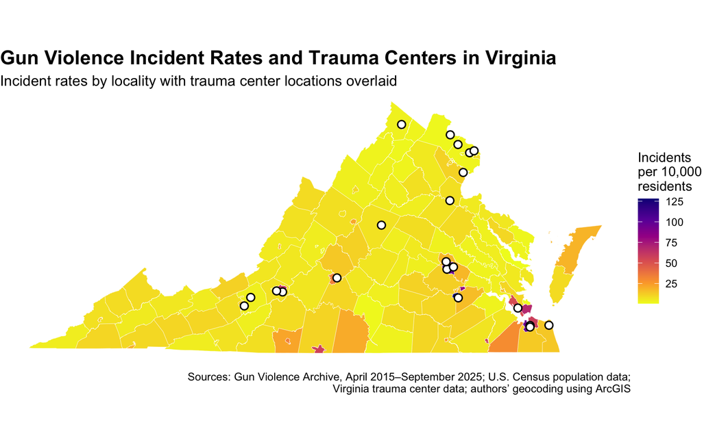

Overlaying trauma center locations with locality-level gun violence rates reveals that access to trauma care is concentrated in urban areas, but this access does not fully explain variation in incident rates or fatal outcomes. High-violence localities exist both near and far from trauma centers, suggesting that proximity to care alone is not a primary driver of differences in outcomes.

Instead, these patterns point to the importance of structural and administrative factors. Differences in reporting practices, data infrastructure, and local capacity may shape how incidents are recorded, potentially inflating or understating violence in certain areas. This reinforces a key limitation of the data: observed differences across localities may reflect variation in measurement as much as variation in underlying violence.

At the same time, the concentration of incidents in cities like Norfolk highlights the localized nature of gun violence and its broader impacts. The cost of treating a single firearm injury can reach up to $232,000, and these incidents impose long-term health and economic burdens on communities (Joint Legislative Audit and Review Commission 2025). This reinforces that gun violence is not only a public safety issue but also a public health and economic one.

Local responses further reflect this pattern. For example, Norfolk has implemented coordinated crime reduction strategies that emphasize community partnerships and targeted interventions in high-incidence areas (City of Norfolk 2022).

# Hot Spots

To identify gun violence hotspots, incidents were grouped based on geographic proximity using latitude and longitude coordinates. Locations were rounded to three decimal places, clustering incidents within approximately one mile of each other. To improve accuracy, only high-confidence addresses (scores above 80) were included. This approach allows for the identification of localized areas with repeated incidents.

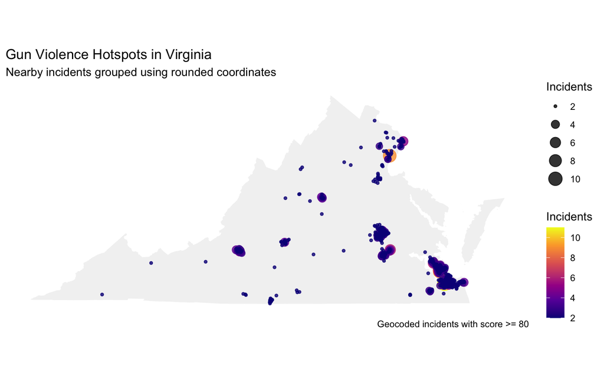

The resulting hotspot map shows that gun violence in Virginia is highly concentrated in specific locations rather than evenly distributed across space. A small number of areas—particularly in urban regions such as Norfolk, Portsmouth, and Richmond account for a disproportionate share of incidents.

This concentration suggests that gun violence is a localized phenomenon driven by specific environmental and social conditions, rather than a uniformly distributed statewide issue. As a result, locality-level averages may mask important within-area variation, where repeated incidents occur in the same neighborhoods or corridors.

From a policy perspective, these patterns indicate that interventions are likely to be most effective when targeted geographically. Place-based strategies—such as focused deterrence or community violence interruption—can be directed toward these high-incidence areas rather than applied broadly across entire regions.

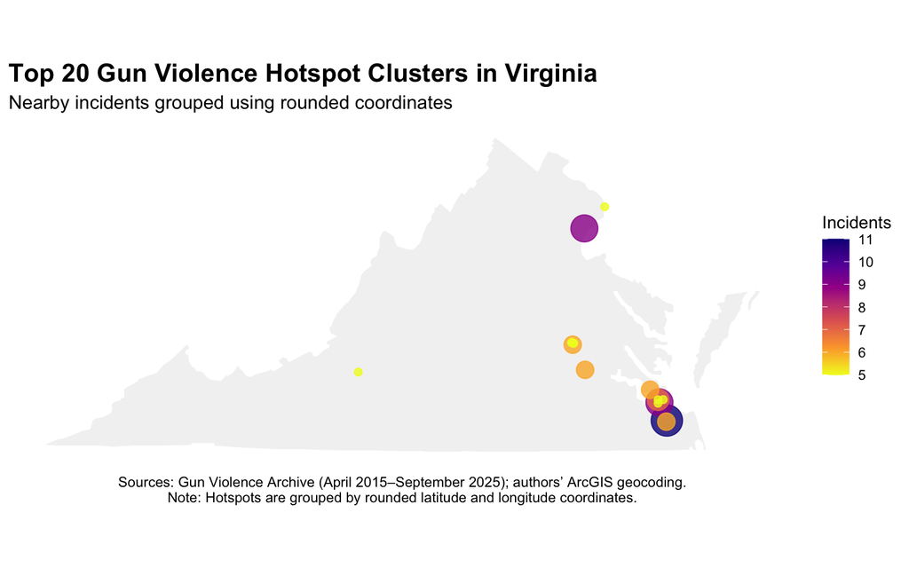

The map of the top 20 hotspot clusters shows that gun violence in Virginia is highly concentrated in a small number of geographic areas rather than spread evenly across the state. The largest and most intense clusters are located in the Hampton Roads region, particularly around Norfolk and Portsmouth, where multiple high-frequency hotspots appear in close proximity. In contrast, other parts of the state show relatively few or smaller clusters, indicating lower levels of repeated incidents. The size and color intensity of clusters further reinforce that a small number of locations account for the highest frequency of incidents.

This pattern highlights that gun violence is driven by localized dynamics, with a small number of areas accounting for a disproportionate share of incidents. Even within high-incidence regions, the clustering suggests that violence is occurring repeatedly in specific neighborhoods or corridors rather than across entire cities.

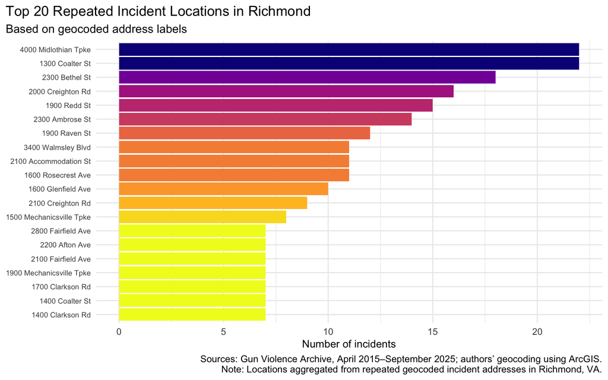

The distribution of repeated incident locations in Richmond reflects a clear “high-concentration hotspot” pattern. A small number of addresses—particularly along Midlothian Tpke and in the Creighton Rd and Coalter St areas—experience significantly higher incident frequency than the rest of the city. At the same time, a broader set of streets show consistent, moderate levels of repeated incidents. This indicates that gun violence in Richmond is both intensely place-based and geographically dispersed, suggesting the need for interventions that combine targeted hotspot strategies with wider corridor-level approaches.

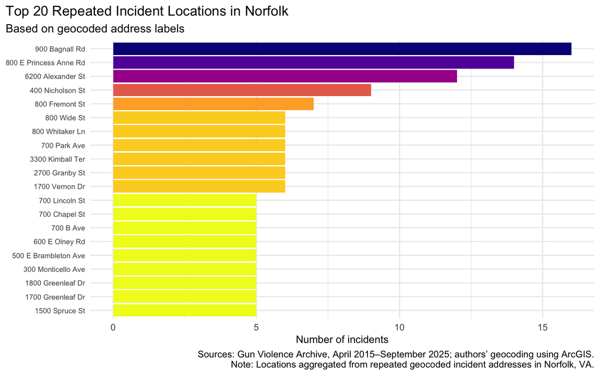

Gun violence incidents in Norfolk exhibit a clustered pattern, with a small number of locations accounting for a disproportionate share of repeated incidents. The most prominent hotspot—900 Bagnall Rd—stands out clearly, followed by several secondary clusters such as E Princess Anne Rd and Alexander St. After the top tier, the distribution flattens, with many locations experiencing similar, moderate levels of repeated incidents. This pattern suggests that while targeted interventions at specific high-frequency sites may be effective, violence is not confined to a single area but dispersed across multiple corridors and neighborhoods.

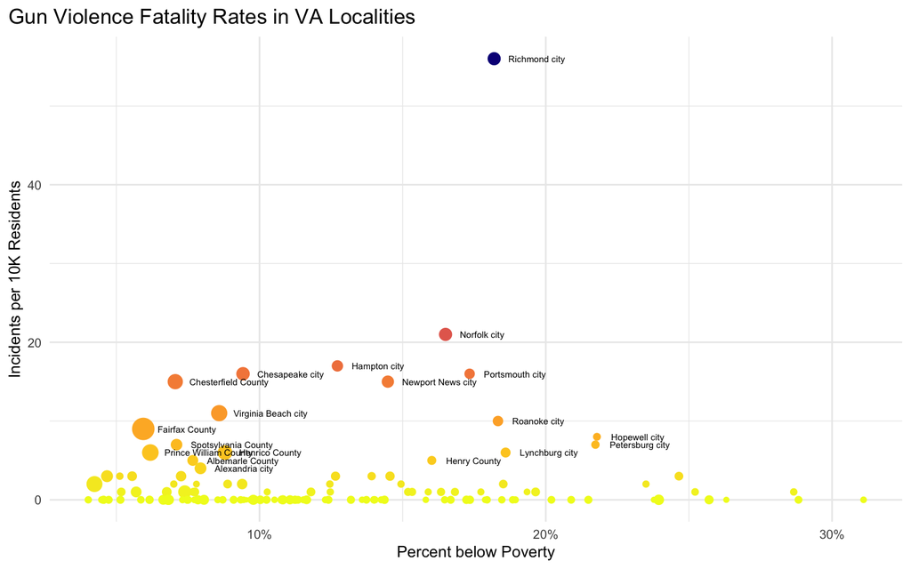

This scatterplot illustrates the relationship between poverty levels and gun violence incident rates across localities in Virginia. The x-axis represents the percentage of residents living below the poverty line, while the y-axis shows incidents per 10,000 residents. Each point corresponds to a locality, with color intensity reflecting higher incident rates. Most localities indicate low incident rates at lower poverty levels.As the percentage of residents below the poverty line increases, there is greater variability in incident rates. Some localities with higher poverty levels show higher incident rates, while others display low values, suggesting that poverty alone is not the sole factor. Cities such as Hopewell, Richmond, and Petersburg appear to have elevated poverty levels alongside higher incident rates.

Overall, the scatterplot suggests a weak positive relationship between poverty and gun violence incidents. Higher poverty is associated with greater variation and, in some instances, higher incident rates. However, many localities with high poverty rates still have low incident rates, indicating that other factors likely contribute to the observed pattern.

The identification of localized hotspots suggests that interventions may be most effective when targeted at specific neighborhoods rather than applied uniformly across regions. Similarly, while proximity to trauma centers shows only a modest relationship with fatal outcomes, it may still play a role when combined with response time and resource availability.

# Limitations

This analysis is subject to several limitations related to data consistency, measurement, and interpretation. First, there is no universally accepted definition of gun violence or related terms such as “school shooting,” which can vary across data sources and affect how incidents are classified and counted (Blad 2023). As a result, comparisons across datasets may reflect differences in definitions as much as differences in underlying trends.

Second, the data used in this analysis rely on reported incidents, which may vary in accuracy and completeness across localities. Differences in reporting practices, administrative capacity, and data infrastructure can influence the number of recorded incidents, potentially leading to over- or underrepresentation of gun violence in certain areas.

Third, while this analysis identifies spatial patterns and hotspots, it does not fully capture the underlying causes of gun violence. Factors such as socioeconomic conditions, community dynamics, and access to firearms likely contribute to the observed patterns but are not directly measured here. Additionally, public perceptions of gun violence may be shaped by media coverage that does not always reflect the true distribution of incidents (Bagley et al. 2026).

# Next Steps

- Future research should focus on improving measurement consistency across data sources by developing standardized definitions of gun violence and integrating datasets such as EveryShot and the Gun Violence Archive.
- Additional analysis should incorporate per capita and severity-based measures at the city level to better capture differences in both frequency and impact of incidents. Expanding the trauma access analysis to include emergency response times and urban–rural differences may provide further insight into fatality outcomes.
- Linking identified hotspots to neighborhood-level socioeconomic characteristics would allow for a deeper understanding of structural drivers of gun violence. Finally, future work should evaluate the effectiveness of local policy strategies, such as data driven in policing and community-based interventions, while also accounting for potential reporting biases across jurisdictions.

# References

Bagley, R., S. Burtner, Andrew V. Papachristos, and Rob Voigt. 2026. “Quantifying Racial Disparities in Media Representations of Gun Violence at Scale.” *Proceedings of the National Academy of Sciences* 123 (3): e2505499123.

Blad, E. 2023. “What Counts as a School Shooting? Lawmakers Want an Official Definition.” *Education Week*. https://www.edweek.org/leadership/what-counts-as-a-school-shooting-lawmakers-want-an-official-definition/2023/04.

City of Norfolk. 2022. “Current and Future Efforts to Address Crime: Crime Reduction Strategies Report.” City of Norfolk. https://www.norfolk.gov/DocumentCenter/View/73566/CMO-Crime-Reduction-Strategies-Report_Final-Draft.

Johns Hopkins Center for Gun Violence Solutions. n.d. “State Gun Violence Data: Virginia.” Johns Hopkins Bloomberg School of Public Health. n.d. https://publichealth.jhu.edu/center-for-gun-violence-solutions/data/state-gun-violence-data/virginia#legislative-bills.

Joint Legislative Audit and Review Commission. 2025. “Effects of Community Gun Violence in Virginia.” Report No. 614. Commonwealth of Virginia.

U.S. Congress. 2023. *School Shooting Safety and Preparedness Act*. https://www.congress.gov/bill/118th-congress/house-bill/2869.

Virginia Department of Health. 2026. “Virginia Trauma Centers.” 2026. https://www.vdh.virginia.gov/emergency-medical-services/trauma-critical-care/virginia-trauma-centers/.